# Feature Reduction Assistant for Metabolomics

NIST Marine ESB Data Tool Development

FRAMe v1.0: last update March 10, 2017

Report generated 2017-04-12 12:49:59 by [default].  
Loaded dataset ~raw/demo Untargeted_HILIC_UPLC addl info test.csv.

**Dataset initially contained 7386 features.**

- 1601 features removed due to blank contribution **>5%** of mean QC feature area.
- 400 features removed due to presence in **<60%** of QC samples.
- 1592 features removed due to QC RSD **>20%**.
- 2551 features removed due to presence in **<80%** of biological samples.
- 373 features removed due to RSD ratios between biological and QC samples **<120%**.
- 1093 features removed due to median area in biological samples less than **10*LOQ**.
- 1220 features removed due to median area in biological samples less than **50*LOQ**.

**4302 features removed due to combined application of all filters.**

- The reduced dataset containing features passing all filters has been saved to:

  ~reports/demo Untargeted_HILIC_UPLC addl info test_features_remaining.csv.
- A dataset containing features removed by filters has been saved to:

  ~reports/demo Untargeted_HILIC_UPLC addl info test_features_removed.csv.

**Figure 1:** Visual expression of feature filtration by category.

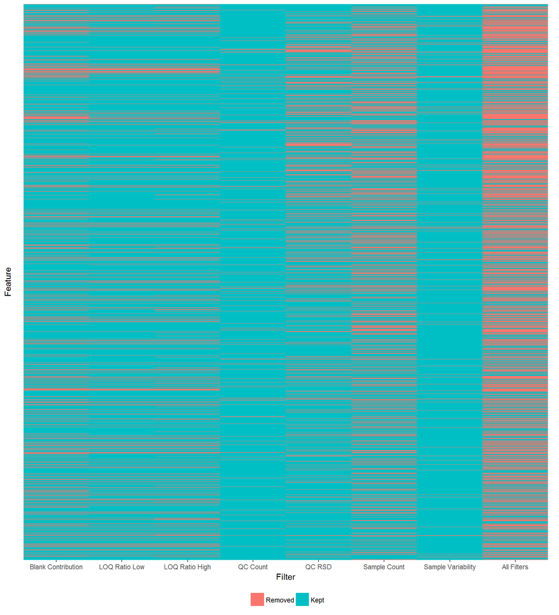

**Figure 2:** Details of filter application effect. Density of occurrence for each filter metric. Red lines indicate the chosen quality thresholds. Only a reasonable range of the density curves are shown.

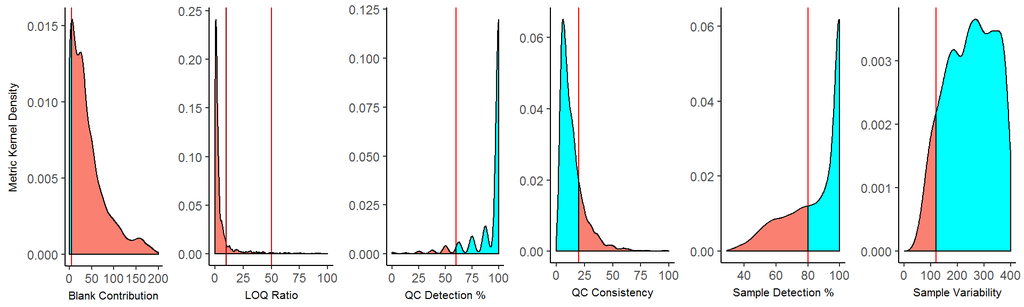